# Insight on Analysis of tweets from the Twitter account WeRateDogs

WeRateDogs is a Twitter account that rates people's dogs with a humorous comment about the dog. These ratings almost always have a denominator of 10. The numerators, though? Almost always greater than 10. 11/10, 12/10, 13/10, etc. Why? Because "they're good dogs Brent." WeRateDogs has over 4 million followers and has received international media coverage.

I did an analysis on the ratings of dogs from the Twitter account to get some insights on the ratings.

For the analysis to be done I had to gather the data I need from Twitter, luckily this data was provided to me by **Udacity** but the provided data lacked some important information for the analysis to be carried out such Favorite counts (likes) and count of retweets for each tweet in my dataset. For the missing information to be gotten, I had to access Twitter using the Twitter API and tweepy library in Python. Although, as at the time of writing this report, my application had not been approved by Twiiter to use their Twitter API, so an already extracted data that contains the needed inforamtion was used. Also another file that contains predictions of the dog breeds for each tweets using Neural network/ Machine learning was provided to me be **Udacity**. After gathering the necessary datasets and wrangling (Accessing and Cleaning) of the dataset for Quality issues and Tidiness, the follwoing were the insights gathered.

1. About 80% of the dogs were rated above 10.
2. The clumber dog breed had the highest average rating.

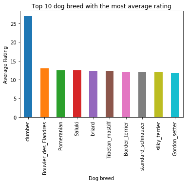

3. Bedlington terrier dog breed has the most average retweet of 7510.

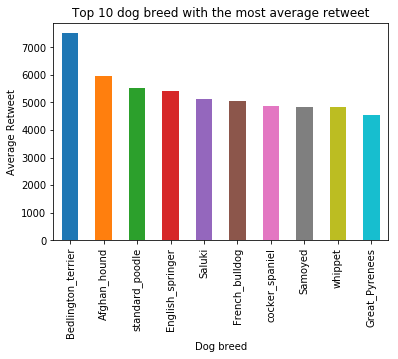

4. Saluki dog breed has the most average like of 24060.

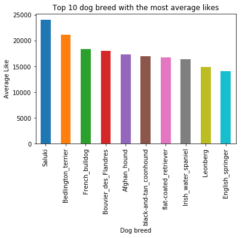

5. The Dog with the most retweet is a Labrador retriever.

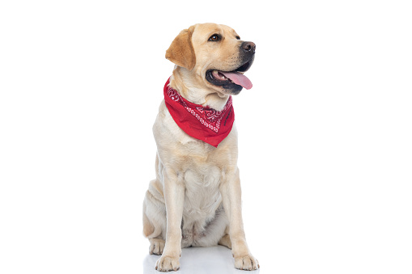

   Below is the chart of the top 10 tweets with most retweets

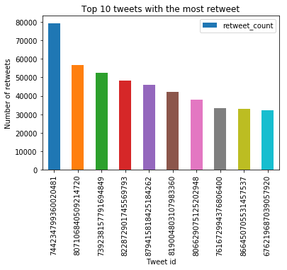

6. The Dog with the most like is a Lakeland terrier.

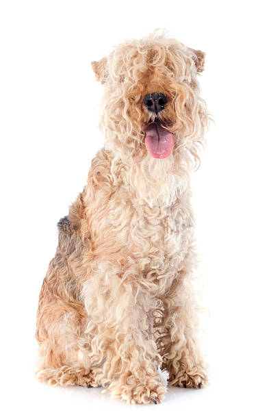

   Below is the chart of the top 10 tweets with most likes

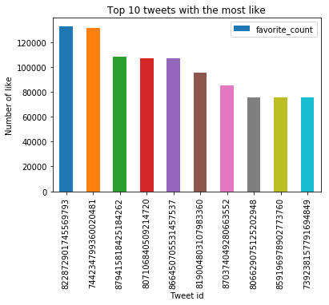